# 1 Cargar y verificar los datos

Primero de todo, cargamos los paquetes que vamos a usar.

```r
library(lattice)
library(ggplot2)
library(caret)
```

Y después, leemos el dataset.

```r
titanic <- read.csv("./train.csv", stringsAsFactors = FALSE, na.strings = c("NA", ""))
str(titanic)
```

```
'data.frame':   891 obs. of  12 variables:
 $ PassengerId: int  1 2 3 4 5 6 7 8 9 10 ...
 $ Survived   : int  0 1 1 1 0 0 0 0 1 1 ...
 $ Pclass     : int  3 1 3 1 3 3 1 3 3 2 ...
 $ Name       : chr  "Braund, Mr. Owen Harris" "Cumings, Mrs. John Bradley (Florence Briggs Thayer)" "Heikkinen, Miss. Laina" "Futrelle, Mrs. Jacques Heath (Lily May Peel)" ...
 $ Sex        : chr  "male" "female" "female" "female" ...
 $ Age        : num  22 38 26 35 35 NA 54 2 27 14 ...
 $ SibSp      : int  1 1 0 1 0 0 0 3 0 1 ...
 $ Parch      : int  0 0 0 0 0 0 0 1 2 0 ...
 $ Ticket     : chr  "A/5 21171" "PC 17599" "STON/O2. 3101282" "113803" ...
 $ Fare       : num  7.25 71.28 7.92 53.1 8.05 ...
 $ Cabin      : chr  NA "C85" NA "C123" ...
 $ Embarked   : chr  "S" "C" "S" "S" ...
```

Nuestra base de datos tiene información sobre 12 variables diferentes de 891 pasajaeros del Titanic.

| Variable Name | Description |
| --- | --- |
| Survived | Survived (1) or died (0) |
| Pclass | Passenger’s class |
| Name | Passenger’s name |
| Sex | Passenger’s sex |
| Age | Passenger’s age |
| SibSp | Number of siblings/spouses aboard |
| Parch | Number of parents/children aboard |
| Ticket | Ticket number |
| Fare | Fare |
| Cabin | Cabin |
| Embarked | Port of embarkation |

# 2 Preprocesamiento

Antes de empezar a trabajar con nuestra base de datos hay que observar como es esta.

Estudiamos cuantos valores unicos hay en cada variable.

```r
lapply(titanic, function(x) length(unique(x)))
```

```
$`PassengerId`
[1] 891

$Survived
[1] 2

$Pclass
[1] 3

$Name
[1] 891

$Sex
[1] 2

$Age
[1] 89

$SibSp
[1] 7

$Parch
[1] 7

$Ticket
[1] 681

$Fare
[1] 248

$Cabin
[1] 148

$Embarked
[1] 4
```

La variable categórica *“PassengerId”* tiene un valor diferente para cada pasajero y en pricipio la descartamos porque no nos aporta ninguna información (habría que preguntar como se creo esa variable para saber si puede contener alguna información). Vamos a hacer lo mismo con la variable categórica *“Ticket”* porque tiene 681 valores diferentes. Con *“Name”* no lo vamos a hacer todavía porque podemos extraer información.

```r
titanic <- subset(titanic, select = -c(PassengerId, Ticket))
```

Estudiamos también, cuantos valores perdidos hay en cada variable.

```r
sapply(titanic, function(x) sum(is.na(x)))
```

```
Survived   Pclass     Name      Sex      Age    SibSp    Parch     Fare    Cabin Embarked
       0        0        0        0      177        0        0        0      687        2
```

Vamos a quitar la variable *“Cabin”* porque tiene muchos valores perdidos y no sabemos como se podrían imputar.

```r
titanic <- subset(titanic, select = -c(Cabin))
```

## 2.1 Extraer información de *Name* y crear la nueva variable *“Title”*

```r
# Extraer el título del nombre
titanic$Title <- gsub('(.*, )|(\\..*)', '', titanic$Name)
# Contar personas en cada categoría de título por sexo
table(titanic$Sex, titanic$Title)
```

```
         Capt Col Don  Dr Jonkheer Lady Major Master Miss Mlle Mme  Mr Mrs  Ms Rev Sir
  female    0   0   0   1        0    1     0      0  182    2   1   0 125   1   0   0
  male      1   2   1   6        1    0     2     40    0    0   0 517   0   0   6   1

         the Countess
  female            1
  male              0
```

```r
# Juntamos los títulos poco frecuentes en la categoría "rare"
rare_title <- c('Dona', 'Lady', 'the Countess','Capt', 'Col', 'Don',
                'Dr', 'Major', 'Rev', 'Sir', 'Jonkheer')
# También, recodificamos mlle, ms, and mme.
titanic$Title[titanic$Title == 'Mlle']        <- 'Miss'
titanic$Title[titanic$Title == 'Ms']          <- 'Miss'
titanic$Title[titanic$Title == 'Mme']         <- 'Mrs'
titanic$Title[titanic$Title %in% rare_title]  <- 'Rare Title'
titanic$Title <- as.factor(titanic$Title)
table(titanic$Sex, titanic$Title)
```

```
         Master Miss  Mr Mrs Rare Title
  female      0  185   0 126          3
  male       40    0 517   0         20
```

Ya hemos extraido información de la variable *“Name”* y no nos hace falta más.

```r
titanic <- subset(titanic, select = -c(Name))
```

## 2.2 Imputar valores perdidos de *“Age”*

Vamos a imputar los valores perdidos en la variable *“Age”* usando la mediana en *“Age”* dependiendo de *“Title”*.

```r
titanic$Age[which(titanic$Title=="Master" & is.na(titanic$Age))] <-
  median(titanic$Age[which(titanic$Title=="Master")], na.rm = TRUE)
titanic$Age[which(titanic$Title=="Miss" & is.na(titanic$Age))] <-
  median(titanic$Age[which(titanic$Title=="Miss")], na.rm = TRUE)
titanic$Age[which(titanic$Title=="Mr" & is.na(titanic$Age))] <-
  median(titanic$Age[which(titanic$Title=="Mr")], na.rm = TRUE)
titanic$Age[which(titanic$Title=="Mrs" & is.na(titanic$Age))] <-
  median(titanic$Age[which(titanic$Title=="Mrs")], na.rm = TRUE)
titanic$Age[which(titanic$Title=="Rare Title" & is.na(titanic$Age))] <-
  median(titanic$Age[which(titanic$Title=="Rare Title")], na.rm = TRUE)
sum(is.na(titanic$Age))
```

```
[1] 0
```

## 2.3 Imputar valores perdidos en *“Embarked”*

Hay dos valores perdidos en la variable *“Embarked”*.

```r
table(titanic$Embarked)
```

```
  C   Q   S
168  77 644
```

Vamos a inferir estos dos valores usando la información de las variables *“Fare”* y *“Pclass”*, que puede que sea la más relevante.

```r
(indexes <- which(is.na(titanic$Embarked)))
```

```
[1]  62 830
```

```r
titanic$Fare[indexes]
```

```
[1] 80 80
```

```r
titanic$Pclass[indexes]
```

```
[1] 1 1
```

Como podemos observar, los dos pasajeros con valor perdido en la variable *“Embarked”* son de la *“Pclass”* 1 y tienen el valor de *“Fare”* 80.

```r
primera <- titanic[which(titanic$Pclass==1),]
boxplot(primera$Fare~primera$Embarked, col="lightseagreen", ylab="Fare", xlab="Embarked")
title(main = "Fare dependiendo de Embarked para los pasajeros de Pclass=1")
```

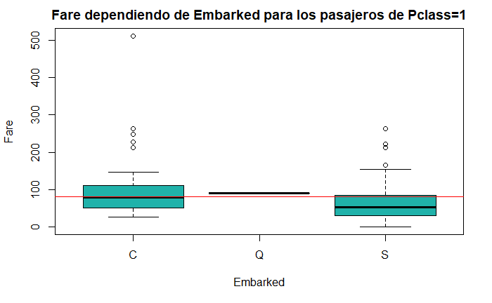

```r
abline(h=80, col="red")
```

Como podemos ver, el valor que mejor se ajusta es “C”. Por lo tanto,

```r
titanic$Embarked[indexes] <- "C"
titanic$Embarked <- factor(titanic$Embarked)
sum(is.na(titanic$Embarked))
```

```
[1] 0
```

## 2.4 Creamos algunas nuevas variables más

### 2.4.1 La nueva variable *“FSize”*

Vamos a crear una variable que nos dija el tamaño de la familia de cada pasajero, incluyendo en ese valor al pasajero.

```r
titanic$Fsize <- titanic$SibSp + titanic$Parch + 1
```

### 2.4.2 La nueva variable *“Child”*

Esta variable nos indicará si el pasajero es un niño o un adulto.

```r
titanic$Child[titanic$Age < 18] <- 'Child'
titanic$Child[titanic$Age >= 18] <- 'Adult'
titanic$Child  <- factor(titanic$Child)
```

### 2.4.3 La nueva variable *“Mother”*

Esta variable nos indicará si la pasajera es madre o no.

```r
titanic$Mother <- 'Not Mother'
titanic$Mother[titanic$Sex == 'female' & titanic$Parch > 0 &
                 titanic$Age > 18 & titanic$Title != 'Miss'] <- 'Mother'
titanic$Mother <- factor(titanic$Mother)
```

# 3 Análisis descriptivo

```r
titanic$Survived <- factor(titanic$Survived, levels=c(0,1))
levels(titanic$Survived) <- c("Died", "Survived")
titanic$Pclass <- as.factor(titanic$Pclass)
levels(titanic$Pclass) <- c("1st Class", "2nd Class", "3rd Class")
titanic$Sex <- as.factor(titanic$Sex)
str(titanic)
```

```
'data.frame':   891 obs. of  12 variables:
 $ Survived: Factor w/ 2 levels "Died","Survived": 1 2 2 2 1 1 1 1 2 2 ...
 $ Pclass  : Factor w/ 3 levels "1st Class","2nd Class",..: 3 1 3 1 3 3 1 3 3 2 ...
 $ Sex     : Factor w/ 2 levels "female","male": 2 1 1 1 2 2 2 2 1 1 ...
 $ Age     : num  22 38 26 35 35 30 54 2 27 14 ...
 $ SibSp   : int  1 1 0 1 0 0 0 3 0 1 ...
 $ Parch   : int  0 0 0 0 0 0 0 1 2 0 ...
 $ Fare    : num  7.25 71.28 7.92 53.1 8.05 ...
 $ Embarked: Factor w/ 3 levels "C","Q","S": 3 1 3 3 3 2 3 3 3 1 ...
 $ Title   : Factor w/ 5 levels "Master","Miss",..: 3 4 2 4 3 3 3 1 4 4 ...
 $ Fsize   : num  2 2 1 2 1 1 1 5 3 2 ...
 $ Child   : Factor w/ 2 levels "Adult","Child": 1 1 1 1 1 1 1 2 1 2 ...
 $ Mother  : Factor w/ 2 levels "Mother","Not Mother": 2 2 2 2 2 2 2 2 1 2 ...
```

```r
for (i in (1:dim(titanic)[2])[-c(4,7)]) {
  print(names(titanic)[i])
  print(table(titanic[,i]))
  cat(round(prop.table(table(titanic[,i])),3),"\n\n")
}
```

```
[1] "Survived"

    Died Survived
     549      342
0.616 0.384

[1] "Pclass"

1st Class 2nd Class 3rd Class
      216       184       491
0.242 0.207 0.551

[1] "Sex"

female   male
   314    577
0.352 0.648

[1] "SibSp"

  0   1   2   3   4   5   8
608 209  28  16  18   5   7
0.682 0.235 0.031 0.018 0.02 0.006 0.008

[1] "Parch"

  0   1   2   3   4   5   6
678 118  80   5   4   5   1
0.761 0.132 0.09 0.006 0.004 0.006 0.001

[1] "Embarked"

  C   Q   S
170  77 644
0.191 0.086 0.723

[1] "Title"

    Master       Miss         Mr        Mrs Rare Title
        40        185        517        126         23
0.045 0.208 0.58 0.141 0.026

[1] "Fsize"

  1   2   3   4   5   6   7   8  11
537 161 102  29  15  22  12   6   7
0.603 0.181 0.114 0.033 0.017 0.025 0.013 0.007 0.008

[1] "Child"

Adult Child
  774   117
0.869 0.131

[1] "Mother"

    Mother Not Mother
        55        836
0.062 0.938
```

Para las variables *Age* y *Fare* vamos a dibujar el histograma y la diagrama de cajas que nos dan información de una forma más visual.

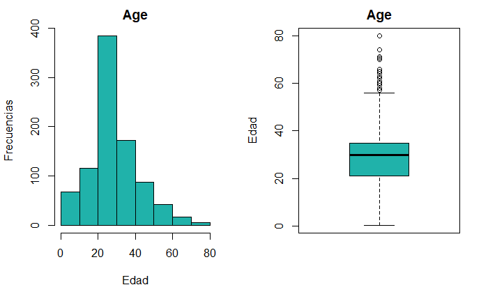

```r
par(mfrow=c(1,2))
hist(titanic$Age, main='Age', ylab='Frecuencias', xlab='Edad', col='lightseagreen')
boxplot(titanic$Age, main='Age', ylab='Edad', col='lightseagreen')
```

```r
hist(titanic$Fare, main='Fare', ylab='Frecuencias', xlab='Tarifa', col='lightseagreen')
boxplot(titanic$Fare, main='Fare', ylab='Tarifa', col='lightseagreen')
```

[figure not shown]

```r
par(mfrow=c(1,1))
```

# 4 Creación de los modelos con el paquete Caret

Antes de aprender un modelo de clasificación es necesario definir las instancias de entrenamiento y test, que darán forma a nuestro modelado. Hay tres opciones de para definir estas instancias.

```r
?createDataPartition
# A series of test/training partitions are created using createDataPartition while createResample creates one or more bootstrap samples. createFolds splits the data into k groups while createTimeSlices creates cross-validation split for series data. groupKFold splits the data based on a grouping factor.
```

Creamos los conjuntos de *train* y *test* con la función *createDataPartition* y la relación de porcentaje de conjunto de datos para cada conjunto sera 70/30.

(Fijamos una semilla para futuras generaciones de numeros aleatorios)

```r
set.seed(107)
inTrain <- createDataPartition(y=titanic$Survived,p=.7,list=FALSE)
training <- titanic[inTrain,]
testing <- titanic[-inTrain,]
```

Usaremos *repeated K-fold cross-validation*.

```r
fitControl <- trainControl(## 10-fold CV
                           method = "repeatedcv",
                           number = 10,
                           ## repeated ten times
                           repeats = 10)
```

## 4.1 Random Forest

For random forests since one feature is never compared in magnitude to other features, the ranges don’t matter. It’s only the range of one feature that is split at each stage.

```r
rf_Model10x10cv <- train(Survived ~ ., data=training, method="rf", trControl=fitControl, metric = "Accuracy")
rf_Model10x10cv
```

```
Random Forest

625 samples
 11 predictor
  2 classes: 'Died', 'Survived'

No pre-processing
Resampling: Cross-Validated (10 fold, repeated 10 times)
Summary of sample sizes: 562, 563, 563, 562, 562, 563, ...
Resampling results across tuning parameters:

  mtry  Accuracy   Kappa
   2    0.8238684  0.6141430
   9    0.8256426  0.6279045
  16    0.8163415  0.6102431

Accuracy was used to select the optimal model using the largest value.
The final value used for the model was mtry = 9.
```

Validación del modelo.

```r
rf_predicted <- predict(rf_Model10x10cv, testing)
confusionMatrix(rf_predicted, testing$Survived)
```

```
Confusion Matrix and Statistics

          Reference
Prediction Died Survived
  Died      145       29
  Survived   19       73

               Accuracy : 0.8195
                 95% CI : (0.768, 0.8638)
    No Information Rate : 0.6165
    P-Value [Acc > NIR] : 5.675e-13

                  Kappa : 0.6112
 Mcnemar's Test P-Value : 0.1939

            Sensitivity : 0.8841
            Specificity : 0.7157
         Pos Pred Value : 0.8333
         Neg Pred Value : 0.7935
             Prevalence : 0.6165
         Detection Rate : 0.5451
   Detection Prevalence : 0.6541
      Balanced Accuracy : 0.7999

       'Positive' Class : Died
```

Obtenemos en un gráfico cuales son las variables más importantes para clasificar a un pasajero como *“Died”*.

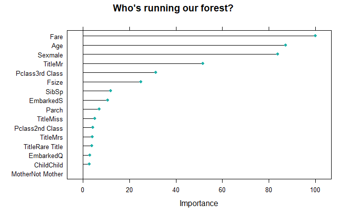

```r
plot(varImp(rf_Model10x10cv),main="Who's running our forest?", col="lightseagreen")
```

## 4.2 Logistic Regression

### 4.2.1 Sin preprocesado

Si usamos el método de la regresión logística sin hacer ningún preprocesado antes, tenemos los siguiente.

```r
glm_Model10x10cv <- train(Survived ~ ., data=training, method="glm", trControl=fitControl, metric="Accuracy")
glm_Model10x10cv
```

```
Generalized Linear Model

625 samples
 11 predictor
  2 classes: 'Died', 'Survived'

No pre-processing
Resampling: Cross-Validated (10 fold, repeated 10 times)
Summary of sample sizes: 562, 563, 562, 562, 562, 563, ...
Resampling results:

  Accuracy   Kappa
  0.8205197  0.6178906
```

### 4.2.2 Quitando variables linealmente dependientes

Si estudiamos y quitamos estas variables (*“FSize”* que es combinación de *“SibSp”* y *“Parch”*; y *“Sex”* que está muy relacionada con *“Title”*) y hacemos de nuevo el training:

```r
glm_Model10x10cv <- train(Survived ~ ., data=training[,-c(3,10)], method="glm", trControl=fitControl, metric="Accuracy")
glm_Model10x10cv
```

```
Generalized Linear Model

625 samples
  9 predictor
  2 classes: 'Died', 'Survived'

No pre-processing
Resampling: Cross-Validated (10 fold, repeated 10 times)
Summary of sample sizes: 562, 562, 562, 563, 563, 562, ...
Resampling results:

  Accuracy   Kappa
  0.8136482  0.6047914
```

```r
glm_predicted <- predict(glm_Model10x10cv, testing[,-c(10)])
confusionMatrix(glm_predicted, testing$Survived)
```

```
Confusion Matrix and Statistics

          Reference
Prediction Died Survived
  Died      147       26
  Survived   17       76

               Accuracy : 0.8383
                 95% CI : (0.7885, 0.8805)
    No Information Rate : 0.6165
    P-Value [Acc > NIR] : 2.231e-15

                  Kappa : 0.6523
 Mcnemar's Test P-Value : 0.2225

            Sensitivity : 0.8963
            Specificity : 0.7451
         Pos Pred Value : 0.8497
         Neg Pred Value : 0.8172
             Prevalence : 0.6165
         Detection Rate : 0.5526
   Detection Prevalence : 0.6504
      Balanced Accuracy : 0.8207

       'Positive' Class : Died
```

### 4.2.3 Haciendo PCA

```r
preProc <- preProcess(training,method="pca",pcaComp=2)
trainingPCA <- predict(preProc,training)
glm_PCA_Model10x10cv <- train(Survived ~ ., data=trainingPCA[,-c(3)], method="glm", trControl=fitControl, metric="Accuracy")
glm_PCA_Model10x10cv
```

```
Generalized Linear Model

625 samples
  7 predictor
  2 classes: 'Died', 'Survived'

No pre-processing
Resampling: Cross-Validated (10 fold, repeated 10 times)
Summary of sample sizes: 562, 563, 563, 562, 563, 562, ...
Resampling results:

  Accuracy   Kappa
  0.8109063  0.5973806
```

```r
testingPCA <- predict(preProc,testing)
glm_PCA_predicted <- predict(glm_PCA_Model10x10cv, testingPCA[,-c(3)])
confusionMatrix(glm_PCA_predicted, testing$Survived)
```

```
Confusion Matrix and Statistics

          Reference
Prediction Died Survived
  Died      144       27
  Survived   20       75

               Accuracy : 0.8233
                 95% CI : (0.7721, 0.8672)
    No Information Rate : 0.6165
    P-Value [Acc > NIR] : 1.974e-13

                  Kappa : 0.6214
 Mcnemar's Test P-Value : 0.3815

            Sensitivity : 0.8780
            Specificity : 0.7353
         Pos Pred Value : 0.8421
         Neg Pred Value : 0.7895
             Prevalence : 0.6165
         Detection Rate : 0.5414
   Detection Prevalence : 0.6429
      Balanced Accuracy : 0.8067

       'Positive' Class : Died
```

## 4.3 Comparativa

Ya que no hemos cambiado la semilla de aleatorización, las particiones (de casos de training) utilizadas en los procesos de “resampling”-validación de cada clasificador han sido las mismas: esto es, las “folds”-hojas del proceso de validación cruzada han sido las mismas en ambos clasificadores.

Por lo tanto, podemos crear gráficos intuitivos como Bland-Altman. Para ello, hemos utilizado la función *resamples* de R, el cual combina los resultados de dos modelos del mismo conjunto de datos (y, como añadido, podemos hacer un resumen numérico de los dos modelos y sus métricas de evaluación utilizando la función genérica de R *summary*). logramos el siguiente gráfico que compara las métricas de *accuracy*:

```r
resamps=resamples(list(rf=rf_Model10x10cv,lr=glm_PCA_Model10x10cv))
summary(resamps)
```

```
Call:
summary.resamples(object = resamps)

Models: rf, lr
Number of resamples: 100

Accuracy
        Min.   1st Qu.    Median      Mean   3rd Qu.      Max. NA's
rf 0.7258065 0.7928187 0.8253968 0.8256426 0.8548387 0.9354839    0
lr 0.6507937 0.7777778 0.8225806 0.8109063 0.8412698 0.9365079    0

Kappa
        Min.   1st Qu.    Median      Mean   3rd Qu.      Max. NA's
rf 0.4085297 0.5561494 0.6327504 0.6279045 0.6924517 0.8640351    0
lr 0.2350993 0.5340166 0.6080206 0.5973806 0.6579805 0.8653846    0
```

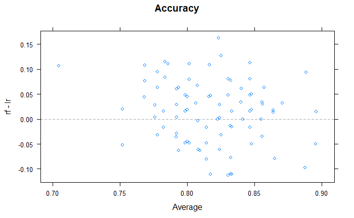

```r
xyplot(resamps,what="BlandAltman")
```

```r
diffs<-diff(resamps)
summary(diffs)
```

```
Call:
summary.diff.resamples(object = diffs)

p-value adjustment: bonferroni
Upper diagonal: estimates of the difference
Lower diagonal: p-value for H0: difference = 0

Accuracy
   rf      lr
rf         0.01474
lr 0.01564

Kappa
   rf      lr
rf         0.03052
lr 0.02077
```

Como vemos, con un nivel de significancia del 5%, se refuta la hipótesis de que los dos modelos no tengan diferencias.